# Lezione DAG

### funghi e variabili ignote

Supponiamo ora che dopo aver fatto l’esperimento ci rendessimo conto di non aver misurato i nutrienti nel terreno. Questi influenzano sia la crescita della pianta, sia la risposta del fungo al trattamento; più nutrienti ci sono più sarà facile per il fungo sopravvivere e allo stesso tempo la pianta crescerà meglio.

Il dag che ne emerge è il seguente:

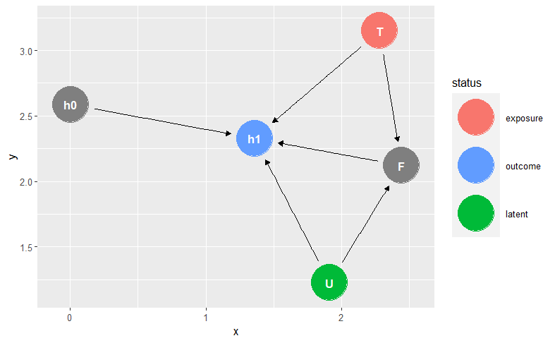

```r
dag_fungus2 <- dagify(
  h1 ~ h0 + F + T + U,
  F ~ T + U,
  exposure = "T",
  outcome = "h1",
  latent = "U"
)
set.seed(1)
ggdag_status(dag_fungus2)
```

`U` indica i nutrienti (di solito le variabili latenti vengono indicate con la lettera U); è una fork su `h1` e `F`. Vediamo ora come introducendo questa variabile cambiano i nostri risultati. Guardiamo innanzitutto i percorsi che ora collegano `T` a `h1`:

| paths | open |
| --- | --- |
| T -> F -> h1 | TRUE |
| T -> F h1 | FALSE |
| T -> h1 | TRUE |

sono diventati 3, con uno passante per `U`, chiuso di default a causa del collider su `F`.

Questo potrebbe creare dei problemi. Proviamo a trovare l’adjustment set per gli effetti totali del trattamento:

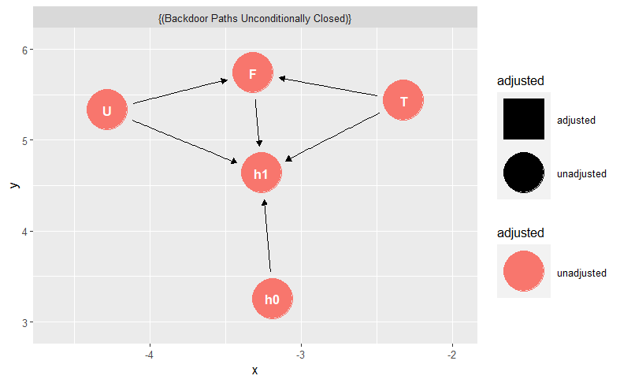

è lo stesso di prima. Proviamo con gli effetti diretti del trattamento:

```
Avvertimento: Failed to close backdoor paths. Common reasons include:
            * graph is not acyclic
            * backdoor paths are not closeable with given set of variables
            * necessary variables are unmeasured (latent)
```

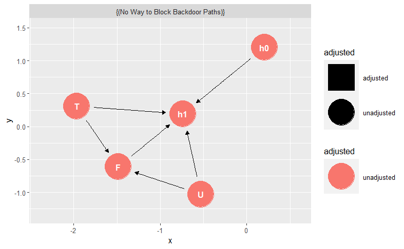

```r
ggdag_adjustment_set(dag_fungus2, effect = "direct")
```

oltre al grafico ggdag ci restituisce un messaggio di avvertimento in cui ci dice che non è riuscito a chiudere tutti i backdoor paths! Quindi non è possibile per noi stimare senza bias l’effetto diretto del trattamento sulla crescita. Bisognerebbe avere i dati sui nutrienti per farlo.

Se cerchiamo di stimare l’effetto del fungo, troveremo lo stesso avvertimento sia per gli effetti totali che per quelli diretti:

```
Avvertimento: Failed to close backdoor paths. Common reasons include:
            * graph is not acyclic
            * backdoor paths are not closeable with given set of variables
            * necessary variables are unmeasured (latent)
```

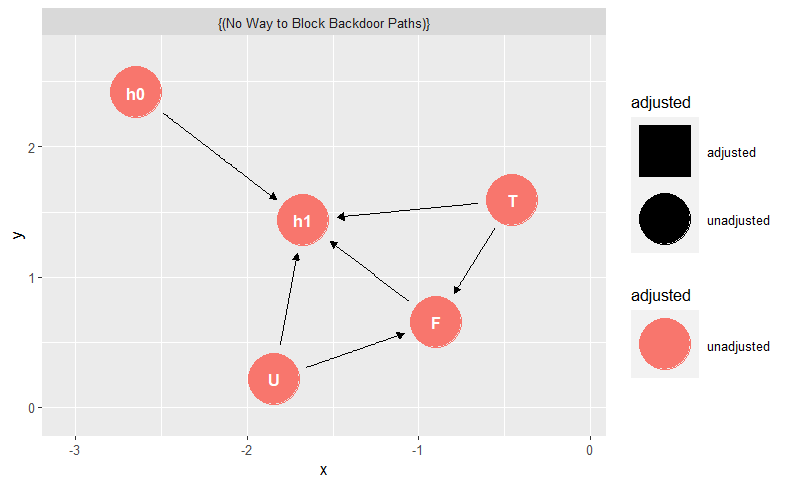

```r
ggdag_adjustment_set(dag_fungus2, exposure = "F", effect = "total")
```

```
Avvertimento: Failed to close backdoor paths. Common reasons include:
            * graph is not acyclic
            * backdoor paths are not closeable with given set of variables
            * necessary variables are unmeasured (latent)
```

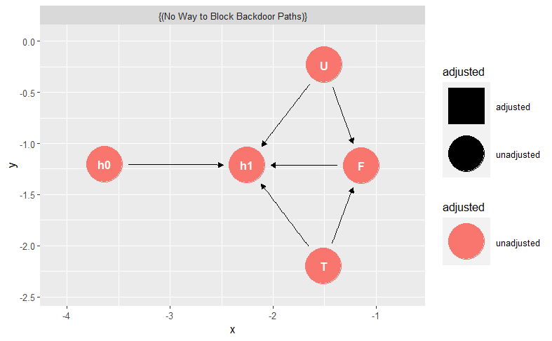

```r
ggdag_adjustment_set(dag_fungus2, exposure = "F", effect = "direct")
```

indicandoci che non è possibile stimare senza bias né l’uno né l’altro. NB: ciò non significa che i coefficienti debbano essere per forza non significativi, significa anche che il loro valore può essere distorto; con l’esempio di adesso quel -4 che abbiamo ottenuto potrebbe essere diverso, ma non sappiamo come: potrebbe avere un effetto dannoso maggiore (-5, -6) o minore (-3, -2). Non possiamo saperlo. Condividerlo però ci aiuta ad essere trasparenti e ad evitare errori di valutazione.

## Uccelli, rapaci e… topolini

I dati all’interno del data-frame `eggs` raccolgono cinquant’anni di dati relativi al numero medio di una determinata specie di piccoli uccelli e al numero di uova deposte da quella specie quell’anno. Insieme a questo sono stati raccolti dati sulla popolazione di rapaci, serpenti e topi presenti nella zona.

| raptors | snakes | mice | eggs | birds |
| --- | --- | --- | --- | --- |
| 19.37355 | 60.39811 | 276.6809 | 2233.076 | 849.6213 |
| 20.18364 | 59.38797 | 309.7552 | 2216.505 | 997.5386 |
| 19.16437 | 60.34112 | 268.5222 | 2157.960 | 981.9851 |
| 21.59528 | 58.87064 | 290.6067 | 2140.945 | 585.2139 |
| 20.32951 | 61.43302 | 230.3726 | 2008.263 | 249.8186 |
| 19.17953 | 61.98040 | 369.2681 | 2033.069 | 1030.6161 |
| 20.48743 | 59.63278 | 330.9941 | 2311.020 | 898.2764 |
| 20.73832 | 58.95587 | 347.9333 | 2169.197 | 770.1043 |
| 20.57578 | 60.56972 | 293.4203 | 2044.466 | 606.0848 |
| 19.69461 | 59.86495 | 394.4446 | 2390.981 | 962.4183 |

[output cut: 40 more lines]

Sappiamo che i rapaci predano la specie di uccelli di nostro interesse; inltre sappiamo che anche la popolazione di serpenti influenza il numero di uova. La popolazione di topi è influenzata sia dai rapaci sia dai serpenti. Il nostro scopo è cercare di capire l’influenza delle uova sulla popolazione di uccelli.

Purtoppo, i dati sulla popolazione di serpenti e rapaci vengono persi e pertanto non sono più disponibili… Il DAG che ne consegue è il seguente:

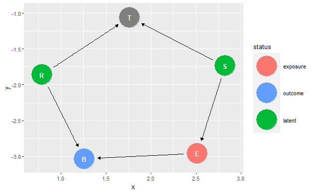

```r
dag_uova <- dagify(
  B ~ E + R,
  E ~ S,
  # S ~ R,
  T ~ R + S,
  exposure = "E",
  outcome = "B",
  latent = c("R", "S")
)
set.seed(1)
ggdag_status(dag_uova)
```

Vediamo i paths:

| paths | open |
| --- | --- |
| E -> B | TRUE |
| E T B | FALSE |

abbiamo due path: uno causale diretto e uno non causale (backdor) chiuso. Già a occhio possiamo concludere che non ci serve nulla come adjustment set, perché tutti i backdoor paths sono chiusi. Verifichiamolo lo stesso:

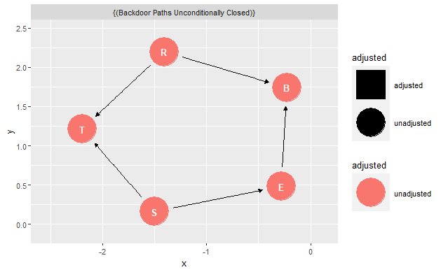

cvd.

Eseguiamo quindi la regressione:

```r
eggs %>% lm(data = ., birds~eggs) %>% summary()
```

```
Call:
lm(formula = birds ~ eggs, data = .)

Residuals:
    Min      1Q  Median      3Q     Max
-414.47  -99.16    0.14  105.94  405.66

Coefficients:
             Estimate Std. Error t value Pr(>|t|)
(Intercept) -673.1904   503.4714  -1.337  0.18749
eggs           0.6385     0.2282   2.799  0.00737 **
---
Signif. codes:  0 ‘***’ 0.001 ‘**’ 0.01 ‘*’ 0.05 ‘.’ 0.1 ‘ ’ 1

Residual standard error: 168.7 on 48 degrees of freedom
Multiple R-squared:  0.1403,    Adjusted R-squared:  0.1224
F-statistic: 7.832 on 1 and 48 DF,  p-value: 0.00737
```

coefficiente significativo con valore di 0.63. Il valore reale con cui sono stati generati i dati è di 0.7. Direi che siamo abbastanza vicini.

Se inserissimo anche la popolazione di topi nella regressione, ne risulterebbe l’apertura del collider, con una conseguente distorsione della stima. Vediamo se è vero:

```r
eggs %>% lm(data = ., birds~eggs + mice) %>% summary()
```

```
Call:
lm(formula = birds ~ eggs + mice, data = .)

Residuals:
    Min      1Q  Median      3Q     Max
-394.53 -109.77    9.65  105.13  330.77

Coefficients:
             Estimate Std. Error t value Pr(>|t|)
(Intercept) -585.5301   503.9709  -1.162   0.2512
eggs           0.5134     0.2454   2.092   0.0418 *
mice           0.6543     0.4948   1.322   0.1925
---
Signif. codes:  0 ‘***’ 0.001 ‘**’ 0.01 ‘*’ 0.05 ‘.’ 0.1 ‘ ’ 1

Residual standard error: 167.4 on 47 degrees of freedom
Multiple R-squared:  0.1711,    Adjusted R-squared:  0.1358
F-statistic: 4.851 on 2 and 47 DF,  p-value: 0.01215
```

il valore è ancora significativo, ma la stima del coefficiente si è allontanata dal valore vero di 0.7. Inoltre il coefficiente della variabile `mice` in questo caso non ha alcun significato.

### stime sempre biased

Tuttavia non abbiamo considerato un’altro fattore: che la popolazione dei serpenti potrebbe essere influenzata dai rapaci. Il DAG diventa quindi:

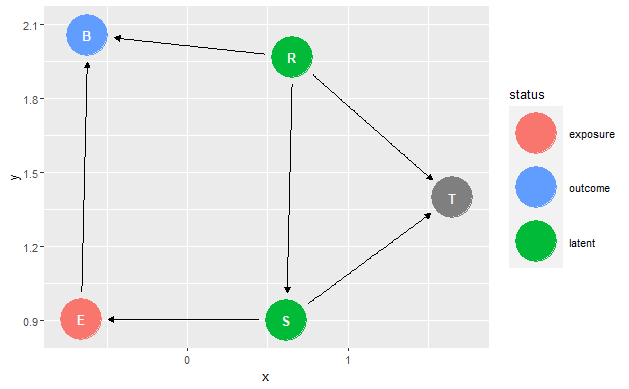

```r
dag_uova1 <- dagify(
  B ~ E + R,
  E ~ S,
  S ~ R,
  T ~ R + S,
  exposure = "E",
  outcome = "B",
  latent = c("R", "S")
)
set.seed(1)
ggdag_status(dag_uova1)
```

questo aggiunge un nuovo path aperto tra `B` ed `E`:

| paths | open |
| --- | --- |
| E -> B | TRUE |
| E T B | FALSE |
| E B | TRUE |

Non solo, con i dati che abbiamo non ci è possibile chiudere questo nuovo path:

```
Avvertimento: Failed to close backdoor paths. Common reasons include:
            * graph is not acyclic
            * backdoor paths are not closeable with given set of variables
            * necessary variables are unmeasured (latent)
```

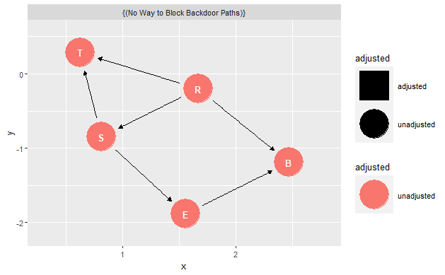

```r
ggdag_adjustment_set(dag_uova1)
```

questo ci indica che con i dati che abbiamo possiamo ottenere solo una stima distorta dell’influenza delle uova sulla popolazione di uccelli. Per di più, se in questo caso usassimo la variabile `mice`, apriremmo un ulteriore backdoor path, senza chiudere il precedente, rendendo la stima ancora più distorta di quello che è.

| paths | open |
| --- | --- |
| E -> B | TRUE |
| E T B | TRUE |
| E B | TRUE |

In somma sintesi in base al DAG che scegliamo di usare possiamo avere una stima distorta o meno della variabile `eggs`. Quale dei due DAG dobbiamo considerare? La scelta sta a voi. Io preferirei il secondo; preferisco affermare che una stima potrebbe essere biased piuttosto che dare la certezza sulla stima. Ma di per sé potreste presentare anche entrambi i DAG e descrivere le conseguenze di sceglierne uno piuttosto che l’altro. La trasparenza è sempre la miglior soluzione in scienza, a mio avviso.

### Riflessioni

Abbiamo visto come assumere un DAG (in altre parole un modello causale) dietro quello che stiamo descrivendo è molto utile per capire come analizzare al meglio i dati. Attraverso i DAG possiamo rimuovere l’influenza delle altre variabili sul nostro effetto causale di interesse (attraverso gli adjustment set) e ci consentono di selezionare le variabili per stimare sia gli effetti totali che gli effetti diretti del nostro trattamento.

Abbiamo anche visto però che questo non è sempre possibile a volte a causa della mancanza di dati che rendono impossibile chiudere i backdoor paths, il che potrebbe rendere la nostra stima perennemente distorta. Tuttavia, sapere che la nostra stima è distorta ci può aiutare nella comprensione del fenomeno, nell’aggiustare il design sperimentale e a prendere maggiormente con le pinze i valori trovati.

Abbiamo anche visto che cambiando la struttura del DAG, specialmente quando introduciamo variabili non misurate o introduciamo altre relazioni che prima non avevamo considerato, è possibile intrpretare diversamente le stime trovate. La domanda sorge spontantea: qual è allora il DAG giusto? Non c’è un DAG giusto o sbagliato. Come ogni aspetto legato alla scienza, quello che possiamo fare è dare la nostra interpetazione del fenomeno al meglio delle conoscenze che abbiamo, e di conseguenza cercare di dedurne il più probabile DAG. Questo vuol dire trasparenza sulle assunzioni e sule stime che ne derivano. Personalmente preferisco l’approccio più conservativo di inserire tutti i confounder che posso trovare e piuttosto essere in dubbio se la stima è distorta piuttosto che dare la certezza su una stima possibilmente errata.

#### README

Se qualcosa non fosse abbastanza chiaro scrivetemi pure all’indirizzo:

matteo.migliorini@univr.it

o aprite una issue su git-hub(?). Alternativamente potete venirmi a trovare; il mio ufficio è di fianco a quello del Prof. Chignola (cv1, ultimo piano, corridoio di sinistra, ultima porta sulla destra, stanza 2.02).

Buono studio e buoni esami :)